# Proyecto de tradind

Daniel Rivera Lloret

2025-11-02

# Proyecto: Comparación de rendimiento entre IA (modelo LSTM) y trading manual

## 1️⃣ Fase 1 – Preguntar

**Problema:** Determinar si el trading automático mediante IA (modelo LSTM) ofrece mejores rendimientos y menor riesgo que el trading manual.

**Objetivos:** - Comparar métricas de rendimiento entre trading manual y automático. - Evaluar consistencia y volatilidad de ambos métodos. - Identificar patrones donde uno supera al otro. - Analizar mejora del modelo LSTM mediante aprendizaje por refuerzo (Q-Learning).

### Preguntas clave

| Pregunta | Detalle | Fuente |
| --- | --- | --- |
| Rendimiento promedio | Eficacia de ambos métodos | Dataset Kakle / Tabla Q LSTM |
| Volatilidad | Evaluar riesgos y estabilidad | Ambos datasets |
| Condiciones de mercado favorables | Identificar patrones | Ambos datasets + indicadores |
| Reducción de errores | Ventaja competitiva | Comparación drawdowns |
| Rentabilidad a largo plazo | Determinar sostenibilidad | Series históricas |
| Mejora con aprendizaje | Evaluar progresión del modelo | Tabla Q LSTM |
| Riesgos y limitaciones | Factores humanos, éticos, seguridad | Documentación IA |

### Hipótesis

- **H1:** IA tendrá rendimiento promedio superior.
- **H2:** IA mostrará menor volatilidad.
- **H3:** Trading manual fallará más en mercados volátiles.
- **H4:** IA detectará patrones no evidentes para humanos.
- **H5:** LSTM mejora con aprendizaje por refuerzo.
- **H6:** Uso de IA conlleva riesgos éticos y tecnológicos.

### Fuentes de datos

| Fuente | Tipo | Uso |
| --- | --- | --- |
| Kakle | Trading manual histórico | Comparación con LSTM |
| Tabla Q LSTM | Predicciones, recompensas, decisiones | Análisis de rendimiento y aprendizaje |

### Formato de datos / Problemas posibles

- **Kakle:** CSV/Excel con precios, decisiones, fechas. Problemas: valores faltantes, inconsistencias, zonas horarias.
- **Tabla Q LSTM:** Dataframe con estados, acciones, recompensas. Problemas: normalización, alineación temporal, sobreajuste, interpretabilidad limitada.

### Stakeholders

- Analista: ejecución y documentación.
- Equipo académico: revisión metodológica.
- Futuro equipo financiero: uso de hallazgos para decisiones.

### Pros y Contras

| Enfoque | Pros | Contras |
| --- | --- | --- |
| Manual | Experiencia humana, flexibilidad | Errores, fatiga, difícil de escalar |
| IA LSTM | Consistencia, procesa gran volumen | Requiere entrenamiento, condiciones no vistas, interpretabilidad limitada |

### Documentación

- Documento principal (Notion/Word/Google Docs).
- Jupyter Notebook / Colab para análisis preliminar.
- Carpeta de proyecto: datasets originales, scripts, exportaciones.

### Código Fase 2 – Preparar

```r
# Instalación de paquetes
install.packages("tidyverse")
install.packages("DBI")
install.packages("dbplyr")
install.packages("RPostgres")
install.packages("lubridate")
install.packages("PerformanceAnalytics")
install.packages("xts")
install.packages("zoo")
install.packages("quantmod")
# Librerías
library(tidyverse)
library(DBI)
library(DBI)
library(dbplyr)
library(RPostgres)
library(lubridate)
library(PerformanceAnalytics)
library(zoo)
library(xts)
library(quantmod)
# Conexión PostgreSQL
con <- dbConnect(
  RPostgres::Postgres(),
  dbname = "trading_project_coursera",
  host = "localhost",
  port = 5432,
  user = "danielmarcos",
  password = "86028602Da"
)

# Cargar datasets desde CSV
ruta_archivos <- "~/Descargas/"
keras_q_indicadores <- read_csv(paste0(ruta_archivos, "keras_q_indicadores.csv"))
keras_q_operaciones <- read_csv(paste0(ruta_archivos, "keras_q_operaciones.csv"))
```

```
## ──────────────────────────────────────────────────────── Delimiter: "," chr
## (2): OPEN_LONG, ...7 dbl (3): 1.0, 101.0, 0.0 lgl (3): ...1, ...2, ...3
```

```r
# Cargar tabla manual
trading_manual <- dbReadTable(con, "trading_manual")

# Verificación rápida
head(keras_q_indicadores)
```

```
## # A tibble: 6 × 8
##   estado accion                         valor_q  iter action price result profit
##   <chr>  <chr>                          <chr>   <dbl> <chr>  <dbl> <chr>   <dbl>
## 1 action "open                      10… HOLD       NA <NA>      NA <NA>       NA
## 2 action "open                      10… SELL       NA <NA>      NA <NA>       NA
## 3 action "open                      10… SELL       NA <NA>      NA <NA>       NA
## 4 action "open                      10… SELL       NA <NA>      NA <NA>       NA
## 5 action "open                      10… BUY        NA <NA>      NA <NA>       NA
## 6 action "open                      10… HOLD       NA <NA>      NA <NA>       NA
```

```r
head(keras_q_operaciones)
```

```
## # A tibble: 6 × 8
##   ...1  ...2  ...3  `1.0` OPEN_LONG   `101.0` ...7  `0.0`
##   <lgl> <lgl> <lgl> <dbl> <chr>         <dbl> <chr> <dbl>
## 1 NA    NA    NA        3 CLOSE_LONG    102.  WIN   0.971
## 2 NA    NA    NA        5 OPEN_SHORT    103   <NA>  0
## 3 NA    NA    NA        7 CLOSE_SHORT   101.  WIN   1.67
## 4 NA    NA    NA        9 OPEN_LONG      98.8 <NA>  0
## 5 NA    NA    NA       10 CLOSE_LONG     99.7 WIN   0.384
## 6 NA    NA    NA       11 OPEN_LONG     100.  <NA>  0
```

```r
head(trading_manual)
```

```
##                                      account  coin Execution.Price Size.Tokens
## 1 0x72c6a4624e1dffa724e6d00d64ceae698af892a0 KAITO           1.822   2000.0000
## 2 0x513b8629fe877bb581bf244e326a047b249c4ff1  HYPE          15.071      0.0400
## 3 0x513b8629fe877bb581bf244e326a047b249c4ff1   BTC       94810.000      0.0060
## 4 0x083384f897ee0f19899168e3b1bec365f52a9012   ETH        3164.600      0.0795
## 5 0x083384f897ee0f19899168e3b1bec365f52a9012   ETH        2715.000      0.2000
## 6 0x4f93fead39b70a1824f981a54d4e55b278e9f760   ETH        3375.900      5.3319
##   Size.USD side Start.Position  direction Closed.PnL
## 1  3644.00  BUY      5000.0000  open long   0.000000
## 2     0.60 SELL         0.0400 close long   0.019728
## 3   568.86 SELL        27.9318 close long   1.635600
## 4   251.59 SELL      -439.2469 open short   0.000000
## 5   543.00 SELL        28.5635 close long  10.658000
## 6 17999.96  BUY         0.0000  open long   0.000000
##                                                     Transaction.Hash
## 1 0x8f3d7f4ec1e03d544a4c041ed9c73901b500a0b3b0e1aad37ffa1aec2f05e771
## 2 0x1255e6be00ce4b74c65f041fe11d0a02011e00ce8a229f678a97ae2a697b630c
## 3 0x2d23432c86d6bada401604226e95a9020166003bd9dd060f398e9bed38b000c7
## 4 0xfb8c265fe0384c05dee304171fa3c80203610102dbb71823cd119c2f5641a3d4
## 5 0x65493b86a46ffe993326041d10ff730204db00466c1bcb9fa3f85a5576f36561
## 6 0x732c9122727841f5b8d2040c7e8c6f013700c4b1298c113bc847d70c125c2bd8
##      Order.ID crossed      fee Trade.ID
## 1 75494536278   FALSE 0.349824        2
## 2 80822037425   FALSE 0.000057        1
## 3 89609661670   FALSE 0.000000        4
## 4 48323391431   FALSE 0.025158        2
## 5 69064166553   FALSE 0.027150        6
## 6 27841730008    TRUE 6.299986        6
```

```r
str(keras_q_indicadores)
```

```
## spc_tbl_ [5,426 × 8] (S3: spec_tbl_df/tbl_df/tbl/data.frame)
##  $ estado : chr [1:5426] "action" "action" "action" "action" ...
##  $ accion : chr [1:5426] "open                      102376.7\nhigh                      102500.0\nlow                       101549.3\nclo"| __truncated__ "open                      102466.5\nhigh                      102869.9\nlow                       102019.7\nclo"| __truncated__ "open         …
##  $ valor_q: chr [1:5426] "HOLD" "SELL" "SELL" "SELL" ...
##  $ iter   : num [1:5426] NA NA NA NA NA NA NA NA NA NA ...
##  $ action : chr [1:5426] NA NA NA NA ...
##  $ price  : num [1:5426] NA NA NA NA NA NA NA NA NA NA ...
##  $ result : chr [1:5426] NA NA NA NA ...
##  $ profit : num [1:5426] NA NA NA NA NA NA NA NA NA NA ...
##  - attr(*, "spec")=
##   .. cols(
##   ..   estado = col_character(),
##   ..   accion = col_character(),
##   ..   valor_q = col_character(),
##   ..   iter = col_double(),
##   ..   action = col_character(),
##   ..   price = col_double(),
##   ..   result = col_character(),
##   ..   profit = col_double()
##   .. )
##  - attr(*, "problems")=<externalptr>
```

```r
str(keras_q_operaciones)
```

```
## spc_tbl_ [3,081 × 8] (S3: spec_tbl_df/tbl_df/tbl/data.frame)
##  $ ...1     : logi [1:3081] NA NA NA NA NA NA ...
##  $ ...2     : logi [1:3081] NA NA NA NA NA NA ...
##  $ ...3     : logi [1:3081] NA NA NA NA NA NA ...
##  $ 1.0      : num [1:3081] 3 5 7 9 10 11 13 2 4 6 ...
##  $ OPEN_LONG: chr [1:3081] "CLOSE_LONG" "OPEN_SHORT" "CLOSE_SHORT" "OPEN_LONG" ...
##  $ 101.0    : num [1:3081] 102.5 103 100.8 98.8 99.7 ...
##  $ ...7     : chr [1:3081] "WIN" NA "WIN" NA ...
##  $ 0.0      : num [1:3081] 0.971 0 1.67 0 0.384 ...
##  - attr(*, "spec")=
##   .. cols(
##   ..   ...1 = col_logical(),
##   ..   ...2 = col_logical(),
##   ..   ...3 = col_logical(),
##   ..   `1.0` = col_double(),
##   ..   OPEN_LONG = col_character(),
##   ..   `101.0` = col_double(),
##   ..   ...7 = col_character(),
##   ..   `0.0` = col_double()
##   .. )
##  - attr(*, "problems")=<externalptr>
```

```r
str(trading_manual)
```

```
## 'data.frame':    101184 obs. of  14 variables:
##  $ account         : chr  "0x72c6a4624e1dffa724e6d00d64ceae698af892a0" "0x513b8629fe877bb581bf244e326a047b249c4ff1" "0x513b8629fe877bb581bf244e326a047b249c4ff1" "0x083384f897ee0f19899168e3b1bec365f52a9012" ...
##  $ coin            : chr  "KAITO" "HYPE" "BTC" "ETH" ...
##  $ Execution.Price : num  1.82 15.07 94810 3164.6 2715 ...
##  $ Size.Tokens     : num  2.00e+03 4.00e-02 6.00e-03 7.95e-02 2.00e-01 ...
##  $ Size.USD        : num  3644 0.6 568.9 251.6 543 ...
##  $ side            : chr  "BUY" "SELL" "SELL" "SELL" ...
##  $ Start.Position  : num  5000 0.04 27.93 -439.25 28.56 ...
##  $ direction       : chr  "open long" "close long" "close long" "open short" ...
##  $ Closed.PnL      : num  0 0.0197 1.6356 0 10.658 ...
##  $ Transaction.Hash: chr  "0x8f3d7f4ec1e03d544a4c041ed9c73901b500a0b3b0e1aad37ffa1aec2f05e771" "0x1255e6be00ce4b74c65f041fe11d0a02011e00ce8a229f678a97ae2a697b630c" "0x2d23432c86d6bada401604226e95a9020166003bd9dd060f398e9bed38b000c7" "0xfb8c265fe0384c05dee304171fa3c80203610102dbb71823cd119c2f5641a…
##  $ Order.ID        : chr  "75494536278" "80822037425" "89609661670" "48323391431" ...
##  $ crossed         : logi  FALSE FALSE FALSE FALSE FALSE TRUE ...
##  $ fee             : num  0.349824 0.000057 0 0.025158 0.02715 ...
##  $ Trade.ID        : num  2 1 4 2 6 6 2 9 7 9 ...
```

```r
colnames(keras_q_indicadores)
```

```
## [1] "estado"  "accion"  "valor_q" "iter"    "action"  "price"   "result"
## [8] "profit"
```

```r
colnames(keras_q_operaciones)
```

```
## [1] "...1"      "...2"      "...3"      "1.0"       "OPEN_LONG" "101.0"
## [7] "...7"      "0.0"
```

```r
colnames(trading_manual)
```

```
##  [1] "account"          "coin"             "Execution.Price"  "Size.Tokens"
##  [5] "Size.USD"         "side"             "Start.Position"   "direction"
##  [9] "Closed.PnL"       "Transaction.Hash" "Order.ID"         "crossed"
## [13] "fee"              "Trade.ID"
```

## Resumen de la Fase 2

Datos IA (LSTM): Estados, acciones, recompensas. Fuente: Aegis-IA0003.keras_q_table.csv. Se dividió en keras_q_operaciones y keras_q_indicadores. Trading manual: Histórico de operaciones, cargado en PostgreSQL desde CSV (historical_data_clean.csv). Datos de referencia: Históricos de BTC para contextualizar operaciones. Revisión de calidad: Consistencia de formatos (decimales, eliminación de saltos de línea). Valores faltantes tratados y tipos de datos ajustados. Eliminación de columnas irrelevantes.

## Fase 3 – Procesar

Acciones realizadas:

Etapa Acción Resultado Limpieza Eliminación de nulos, duplicados Tabla Trading_Manual limpia (101.184 registros) Transformación Normalización y alineación de columnas Datos listos para comparación Estructuración Carga final en PostgreSQL Preparado para R y Tableau Decisiones técnicas Conservación outliers, eliminación columnas no relevantes Datasets finales para análisis

```r
# Limpieza y transformación avanzada de los datasets
library(dplyr)
library(stringr)
library(tidyr)

# Eliminar columnas vacías y renombrar las útiles
keras_q_operaciones <- read_csv(
  "~/Descargas/keras_q_operaciones.csv",
  col_names = FALSE  # forzar que R no use la primera fila como header
)
# Ver las primeras filas para asignar nombres correctos
head(keras_q_operaciones)
```

```
## # A tibble: 6 × 8
##   X1    X2    X3       X4 X5             X6 X7       X8
##   <lgl> <lgl> <lgl> <dbl> <chr>       <dbl> <chr> <dbl>
## 1 NA    NA    NA        1 OPEN_LONG   101   <NA>  0
## 2 NA    NA    NA        3 CLOSE_LONG  102.  WIN   0.971
## 3 NA    NA    NA        5 OPEN_SHORT  103   <NA>  0
## 4 NA    NA    NA        7 CLOSE_SHORT 101.  WIN   1.67
## 5 NA    NA    NA        9 OPEN_LONG    98.8 <NA>  0
## 6 NA    NA    NA       10 CLOSE_LONG   99.7 WIN   0.384
```

```r
# Renombrar columnas
colnames(keras_q_operaciones) <- c("ignore1","ignore2","ignore3","iter","accion","precio","resultado","profit")

# Seleccionar solo columnas útiles
keras_q_operaciones <- keras_q_operaciones %>%
  select(iter, accion, precio, resultado, profit) %>%
  mutate(row_id = row_number())

# Revisar resultados
str(keras_q_operaciones)
```

```
## tibble [3,082 × 6] (S3: tbl_df/tbl/data.frame)
##  $ iter     : num [1:3082] 1 3 5 7 9 10 11 13 2 4 ...
##  $ accion   : chr [1:3082] "OPEN_LONG" "CLOSE_LONG" "OPEN_SHORT" "CLOSE_SHORT" ...
##  $ precio   : num [1:3082] 101 102.5 103 100.8 98.8 ...
##  $ resultado: chr [1:3082] NA "WIN" NA "WIN" ...
##  $ profit   : num [1:3082] 0 0.971 0 1.67 0 ...
##  $ row_id   : int [1:3082] 1 2 3 4 5 6 7 8 9 10 ...
```

```r
head(keras_q_operaciones)
```

```
## # A tibble: 6 × 6
##    iter accion      precio resultado profit row_id
##   <dbl> <chr>        <dbl> <chr>      <dbl>  <int>
## 1     1 OPEN_LONG    101   <NA>       0          1
## 2     3 CLOSE_LONG   102.  WIN        0.971      2
## 3     5 OPEN_SHORT   103   <NA>       0          3
## 4     7 CLOSE_SHORT  101.  WIN        1.67       4
## 5     9 OPEN_LONG     98.8 <NA>       0          5
## 6    10 CLOSE_LONG    99.7 WIN        0.384      6
```

```r
summary(keras_q_operaciones)
```

```
##       iter          accion              precio        resultado
##  Min.   :    1   Length:3082        Min.   : 68.40   Length:3082
##  1st Qu.: 1974   Class :character   1st Qu.: 94.68   Class :character
##  Median : 4376   Mode  :character   Median :109.13   Mode  :character
##  Mean   : 8428                      Mean   :110.80
##  3rd Qu.:14712                      3rd Qu.:131.57
##  Max.   :25836                      Max.   :152.37
##      profit            row_id
##  Min.   :-0.9633   Min.   :   1.0
##  1st Qu.: 0.0000   1st Qu.: 771.2
##  Median : 0.3212   Median :1541.5
##  Mean   : 0.3025   Mean   :1541.5
##  3rd Qu.: 0.5136   3rd Qu.:2311.8
##  Max.   : 1.7399   Max.   :3082.0
```

```r
str(keras_q_operaciones)
```

```
## tibble [3,082 × 6] (S3: tbl_df/tbl/data.frame)
##  $ iter     : num [1:3082] 1 3 5 7 9 10 11 13 2 4 ...
##  $ accion   : chr [1:3082] "OPEN_LONG" "CLOSE_LONG" "OPEN_SHORT" "CLOSE_SHORT" ...
##  $ precio   : num [1:3082] 101 102.5 103 100.8 98.8 ...
##  $ resultado: chr [1:3082] NA "WIN" NA "WIN" ...
##  $ profit   : num [1:3082] 0 0.971 0 1.67 0 ...
##  $ row_id   : int [1:3082] 1 2 3 4 5 6 7 8 9 10 ...
```

```r
summary(keras_q_operaciones)
```

```
##       iter          accion              precio        resultado
##  Min.   :    1   Length:3082        Min.   : 68.40   Length:3082
##  1st Qu.: 1974   Class :character   1st Qu.: 94.68   Class :character
##  Median : 4376   Mode  :character   Median :109.13   Mode  :character
##  Mean   : 8428                      Mean   :110.80
##  3rd Qu.:14712                      3rd Qu.:131.57
##  Max.   :25836                      Max.   :152.37
##      profit            row_id
##  Min.   :-0.9633   Min.   :   1.0
##  1st Qu.: 0.0000   1st Qu.: 771.2
##  Median : 0.3212   Median :1541.5
##  Mean   : 0.3025   Mean   :1541.5
##  3rd Qu.: 0.5136   3rd Qu.:2311.8
##  Max.   : 1.7399   Max.   :3082.0
```

```r
# Extraer valores numéricos de la columna accion_bot
library(stringr)
keras_q_indicadores <- keras_q_indicadores %>%
  filter(!is.na(accion)) %>%   # aquí va la columna correcta
  mutate(
    open  = as.numeric(str_match(accion, "open\\s+([0-9\\.]+)")[,2]),
    high  = as.numeric(str_match(accion, "high\\s+([0-9\\.]+)")[,2]),
    low   = as.numeric(str_match(accion, "low\\s+([0-9\\.]+)")[,2]),
    close = as.numeric(str_match(accion, "clo\\S*\\s+([0-9\\.]+)")[,2]),
    row_id = row_number()  # crear row_id antes de select
  ) %>%
  select(open, high, low, close, accion, row_id)

str(keras_q_indicadores)
```

```
## tibble [2,344 × 6] (S3: tbl_df/tbl/data.frame)
##  $ open  : num [1:2344] 102377 102466 102664 101612 101934 ...
##  $ high  : num [1:2344] 102500 102870 102664 102136 102633 ...
##  $ low   : num [1:2344] 101549 102020 101601 101286 101282 ...
##  $ close : num [1:2344] 102466 102664 101654 101934 102455 ...
##  $ accion: chr [1:2344] "open                      102376.7\nhigh                      102500.0\nlow                       101549.3\nclo"| __truncated__ "open                      102466.5\nhigh                      102869.9\nlow                       102019.7\nclo"| __truncated__ "open          …
##  $ row_id: int [1:2344] 1 2 3 4 5 6 7 8 9 10 ...
```

```r
summary(keras_q_indicadores)
```

```
##       open             high             low             close
##  Min.   : 93359   Min.   : 94351   Min.   : 91000   Min.   : 93360
##  1st Qu.: 96627   1st Qu.: 97029   1st Qu.: 96274   1st Qu.: 96626
##  Median : 97868   Median : 98283   Median : 97431   Median : 97773
##  Mean   : 99172   Mean   : 99599   Mean   : 98697   Mean   : 99150
##  3rd Qu.:102073   3rd Qu.:102444   3rd Qu.:101557   3rd Qu.:101999
##  Max.   :106452   Max.   :107081   Max.   :105726   Max.   :106451
##     accion              row_id
##  Length:2344        Min.   :   1.0
##  Class :character   1st Qu.: 586.8
##  Mode  :character   Median :1172.5
##                     Mean   :1172.5
##                     3rd Qu.:1758.2
##                     Max.   :2344.0
```

```r
# Unir los datasets del bot por row_id
keras_q_operaciones <- keras_q_operaciones %>%
  mutate(row_id = row_number())
keras_q_indicadores <- keras_q_indicadores %>%
  mutate(row_id = row_number())

bot_trading <- full_join(keras_q_operaciones, keras_q_indicadores, by = "row_id") %>%
  mutate(tipo = "bot")

glimpse(bot_trading)
```

```
## Rows: 3,082
## Columns: 12
## $ iter      <dbl> 1, 3, 5, 7, 9, 10, 11, 13, 2, 4, 6, 8, 13, 15, 18, 20, 37, 3…
## $ accion.x  <chr> "OPEN_LONG", "CLOSE_LONG", "OPEN_SHORT", "CLOSE_SHORT", "OPE…
## $ precio    <dbl> 101.00, 102.50, 103.00, 100.80, 98.80, 99.70, 100.40, 102.10…
## $ resultado <chr> NA, "WIN", NA, "WIN", NA, "WIN", NA, "FORCED", NA, "WIN", NA…
## $ profit    <dbl> 0.000000, 0.970900, 0.000000, 1.670120, 0.000000, 0.383900, …
## $ row_id    <int> 1, 2, 3, 4, 5, 6, 7, 8, 9, 10, 11, 12, 13, 14, 15, 16, 17, 1…
## $ open      <dbl> 102376.7, 102466.5, 102664.4, 101612.0, 101933.5, 102454.7, …
## $ high      <dbl> 102500.0, 102869.9, 102664.4, 102136.0, 102633.1, 106000.0, …
## $ low       <dbl> 101549.3, 102019.7, 101601.0, 101285.9, 101281.7, 102001.3, …
## $ close     <dbl> 102466.5, 102664.4, 101654.3, 101933.5, 102454.7, 105230.2, …
## $ accion.y  <chr> "open                      102376.7\nhigh                   …
## $ tipo      <chr> "bot", "bot", "bot", "bot", "bot", "bot", "bot", "bot", "bot…
```

```r
head(bot_trading, 10)
```

```
## # A tibble: 10 × 12
##     iter accion.x     precio resultado profit row_id   open   high    low  close
##    <dbl> <chr>         <dbl> <chr>      <dbl>  <int>  <dbl>  <dbl>  <dbl>  <dbl>
##  1     1 OPEN_LONG     101   <NA>       0          1 1.02e5 1.02e5 1.02e5 1.02e5
##  2     3 CLOSE_LONG    102.  WIN        0.971      2 1.02e5 1.03e5 1.02e5 1.03e5
##  3     5 OPEN_SHORT    103   <NA>       0          3 1.03e5 1.03e5 1.02e5 1.02e5
##  4     7 CLOSE_SHORT   101.  WIN        1.67       4 1.02e5 1.02e5 1.01e5 1.02e5
##  5     9 OPEN_LONG      98.8 <NA>       0          5 1.02e5 1.03e5 1.01e5 1.02e5
##  6    10 CLOSE_LONG     99.7 WIN        0.384      6 1.02e5 1.06e5 1.02e5 1.05e5
##  7    11 OPEN_LONG     100.  <NA>       0          7 1.05e5 1.07e5 1.04e5 1.06e5
##  8    13 FORCED_CLOS…  102.  FORCED     1.17       8 1.06e5 1.06e5 1.03e5 1.04e5
##  9     2 OPEN_LONG     100.  <NA>       0          9 1.04e5 1.06e5 1.02e5 1.03e5
## 10     4 CLOSE_LONG    101.  WIN        0.347     10 1.03e5 1.05e5 1.03e5 1.04e5
## # ℹ 2 more variables: accion.y <chr>, tipo <chr>
```

```r
# Limpiar y transformar dataset de trading manual
trading_manual <- trading_manual %>%
  mutate(
    profit = Closed.PnL - fee,
    tipo = "manual"
  ) %>%
  select(Trade.ID, coin, side, Execution.Price, profit, tipo) %>%
  rename(
    id = Trade.ID,
    asset = coin,
    accion = side,
    precio = Execution.Price
  )

glimpse(trading_manual)
```

```
## Rows: 101,184
## Columns: 6
## $ id     <dbl> 2, 1, 4, 2, 6, 6, 2, 9, 7, 9, 8, 7, 2, 8, 1, 1, 6, 7, 1, 4, 8, …
## $ asset  <chr> "KAITO", "HYPE", "BTC", "ETH", "ETH", "ETH", "MANTA", "kBONK", …
## $ accion <chr> "BUY", "SELL", "SELL", "SELL", "SELL", "BUY", "SELL", "SELL", "…
## $ precio <dbl> 1.8220e+00, 1.5071e+01, 9.4810e+04, 3.1646e+03, 2.7150e+03, 3.3…
## $ profit <dbl> -0.349824, 0.019671, 1.635600, -0.025158, 10.630850, -6.299986,…
## $ tipo   <chr> "manual", "manual", "manual", "manual", "manual", "manual", "ma…
```

```r
summary(trading_manual$profit)
```

```
##       Min.    1st Qu.     Median       Mean    3rd Qu.       Max.
## -118071.56      -0.12       0.00      57.32       4.29  135299.80
```

```r
head(trading_manual, 10)
```

```
##    id    asset accion     precio    profit   tipo
## 1   2    KAITO    BUY 1.8220e+00 -0.349824 manual
## 2   1     HYPE   SELL 1.5071e+01  0.019671 manual
## 3   4      BTC   SELL 9.4810e+04  1.635600 manual
## 4   2      ETH   SELL 3.1646e+03 -0.025158 manual
## 5   6      ETH   SELL 2.7150e+03 10.630850 manual
## 6   6      ETH    BUY 3.3759e+03 -6.299986 manual
## 7   2    MANTA   SELL 3.1657e+00  0.097022 manual
## 8   9    kBONK   SELL 2.8451e-02  0.913541 manual
## 9   7      STX   SELL 3.6173e+00  0.011326 manual
## 10  9 GRIFFAIN    BUY 4.6330e-01  7.475273 manual
```

```r
# Cargar librerías adicionales para análisis financiero
install.packages(c("PerformanceAnalytics", "xts", "zoo", "quantmod"))
library(PerformanceAnalytics)

# Filtrar solo BTC en trading manual
trading_manual_btc <- trading_manual %>% filter(asset == "BTC")

# Crear dataset comparativo con el bot
comparativo_btc <- bind_rows(
  bot_trading %>%
    select(accion = accion.x, precio, profit, tipo) %>%
    mutate(asset = "BTC"),
  trading_manual_btc %>%
    select(accion, precio, profit, tipo, asset)
)

glimpse(comparativo_btc)
```

```
## Rows: 13,217
## Columns: 5
## $ accion <chr> "OPEN_LONG", "CLOSE_LONG", "OPEN_SHORT", "CLOSE_SHORT", "OPEN_L…
## $ precio <dbl> 101.00, 102.50, 103.00, 100.80, 98.80, 99.70, 100.40, 102.10, 1…
## $ profit <dbl> 0.000000, 0.970900, 0.000000, 1.670120, 0.000000, 0.383900, 0.0…
## $ tipo   <chr> "bot", "bot", "bot", "bot", "bot", "bot", "bot", "bot", "bot", …
## $ asset  <chr> "BTC", "BTC", "BTC", "BTC", "BTC", "BTC", "BTC", "BTC", "BTC", …
```

```r
table(comparativo_btc$tipo)
```

```
##
##    bot manual
##   3082  10135
```

# Fase 4 – Analizar: Comparativa entre Trading Manual y Bot (LSTM)

En esta fase se realizó el análisis estadístico y comparativo entre el desempeño del bot LSTM y el trading manual. El objetivo fue evaluar rentabilidad, consistencia y eficiencia operativa bajo métricas cuantitativas y visualizaciones descriptivas.

# Preparación

Se conectaron las bases de datos desde PostgreSQL hacia R utilizando RPostgres y DBI. Posteriormente se limpiaron y estandarizaron los tres conjuntos de datos:

keras_q_indicadores

keras_q_operaciones (bot)

trading_manual

Luego se unificaron en un solo dataset comparativo, agregando la variable tipo con valores “bot” o “manual”.

#Análisis exploratorio

Se inspeccionaron estructuras, columnas y resúmenes (str, summary, colnames), y se generaron métricas descriptivas por tipo: Media, mediana, desviación estándar, varianza, min y max. Sharpe Ratio (retorno ajustado por volatilidad). Drawdown máximo (pérdida acumulada máxima). También se detectó un desequilibrio de volumen operativo: Bot: ~3.000 operaciones. Manual: ~10.000 operaciones.

# Análisis y visualización

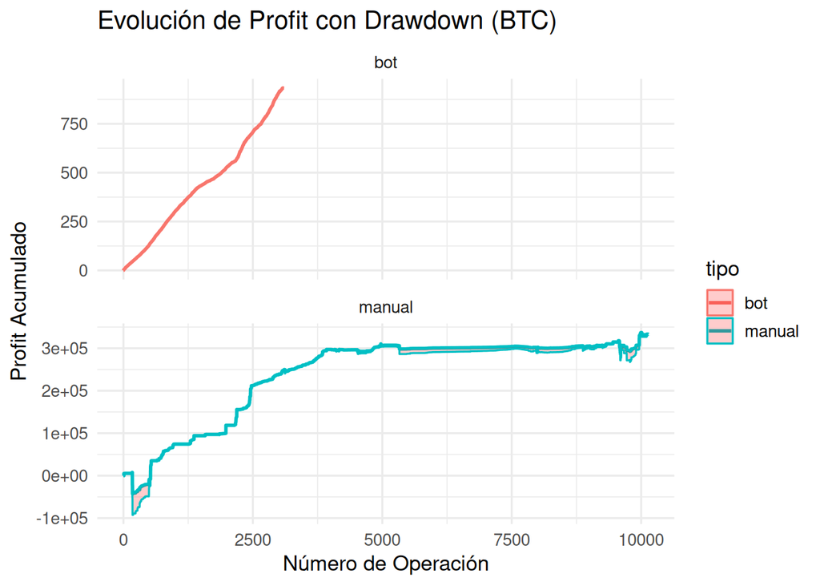

```r
#---------------------------------------------
# MÉTRICAS ESTADÍSTICAS POR TIPO
#---------------------------------------------
metricas_btc <- comparativo_btc %>%
  group_by(tipo) %>%
  summarise(
    operaciones = n(),
    media_profit = mean(profit, na.rm = TRUE),
    mediana_profit = median(profit, na.rm = TRUE),
    sd_profit = sd(profit, na.rm = TRUE),
    var_profit = var(profit, na.rm = TRUE),
    sharpe_ratio = ifelse(sd_profit > 0, media_profit / sd_profit, NA),
    profit_min = min(profit, na.rm = TRUE),
    profit_max = max(profit, na.rm = TRUE)
  )

#---------------------------------------------
# DRAWDOWN (PÉRDIDA MÁXIMA)
#---------------------------------------------
drawdown_btc <- comparativo_btc %>%
  group_by(tipo) %>%
  mutate(
    equity = cumsum(replace_na(profit, 0)),
    drawdown = equity - cummax(equity)
  ) %>%
  summarise(max_drawdown = min(drawdown, na.rm = TRUE))

#---------------------------------------------
# VISUALIZACIONES COMPARATIVAS
#---------------------------------------------

# Equity acumulado + drawdown
comparativo_btc_equity <- comparativo_btc %>%
  group_by(tipo) %>%
  mutate(
    equity = cumsum(replace_na(profit, 0)),
    operacion = row_number(),
    drawdown = equity - cummax(equity)
  )
ggplot(comparativo_btc_equity, aes(x = operacion, y = equity, color = tipo)) +
  geom_line(linewidth = 1) +
  geom_ribbon(aes(ymin = equity + drawdown, ymax = equity),
              alpha = 0.2, fill = "red") +
  facet_wrap(~tipo, scales = "free_y", ncol = 1) +
  labs(title = "Evolución de Profit con Drawdown (BTC)",
       x = "Número de Operación", y = "Profit Acumulado") +
  theme_minimal(base_size = 13)
```

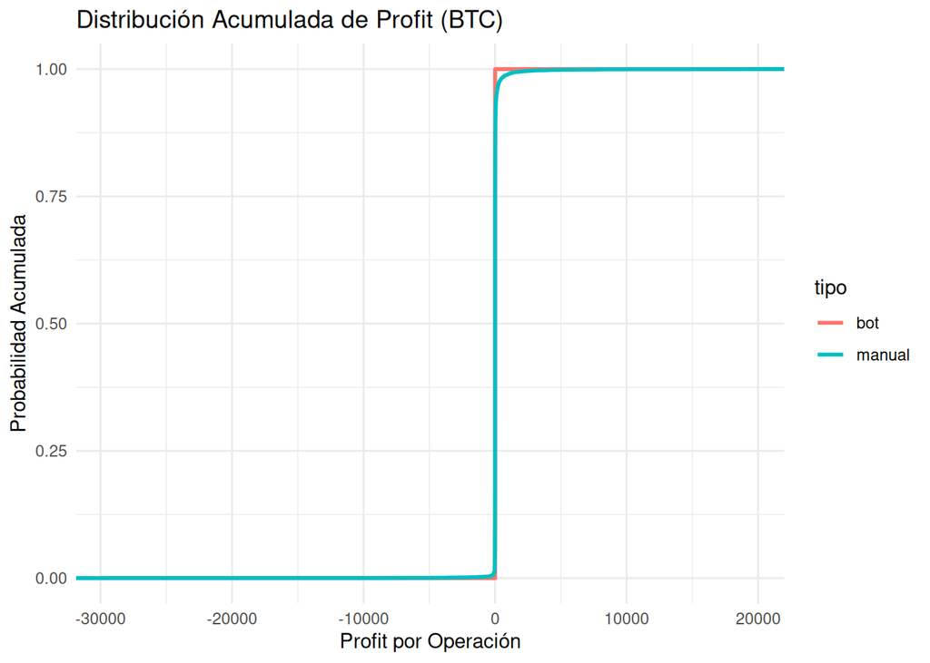

```r
# Distribución acumulada (ECDF)
ggplot(comparativo_btc, aes(x = profit, color = tipo)) +
  stat_ecdf(size = 1) +
  labs(title = "Distribución Acumulada de Profit (BTC)",
       x = "Profit por Operación", y = "Probabilidad Acumulada") +
  theme_minimal()
```

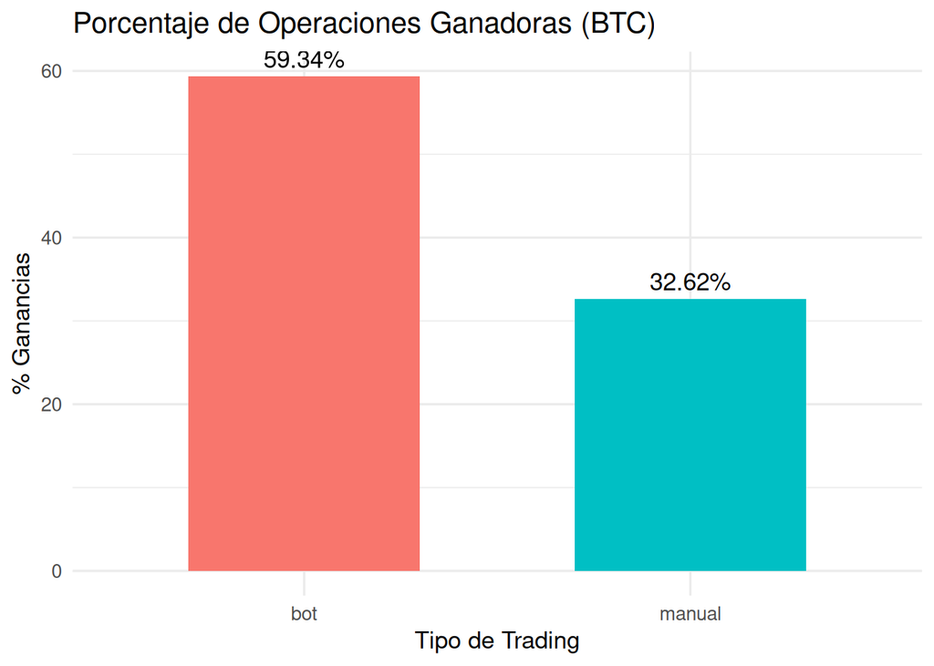

```r
#---------------------------------------------
# TABLA RESUMEN GENERAL
#---------------------------------------------
tabla_resumen_general <- comparativo_btc %>%
  group_by(tipo) %>%
  summarise(
    operaciones_totales = n(),
    ganancias = sum(profit > 0, na.rm = TRUE),
    perdidas = sum(profit < 0, na.rm = TRUE),
    pct_ganancias = round((ganancias / operaciones_totales) * 100, 2),
    media_profit = mean(profit, na.rm = TRUE),
    mediana_profit = median(profit, na.rm = TRUE),
    .groups = "drop"
  )

# Porcentaje de operaciones ganadoras
ggplot(tabla_resumen_general, aes(x = tipo, y = pct_ganancias, fill = tipo)) +
  geom_col(width = 0.6) +
  geom_text(aes(label = paste0(pct_ganancias, "%")), vjust = -0.5) +
  labs(title = "Porcentaje de Operaciones Ganadoras (BTC)",
       x = "Tipo de Trading", y = "% Ganancias") +
  theme_minimal(base_size = 13) +
  theme(legend.position = "none")
```

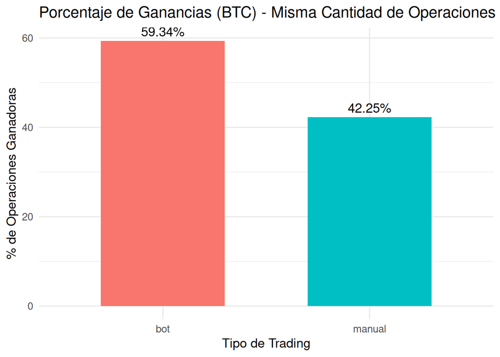

```r
#---------------------------------------------
# IGUALAR CANTIDAD DE OPERACIONES
#---------------------------------------------
n_igual <- min(tabla_resumen_general$operaciones_totales)
set.seed(123)
comparativo_btc_equal <- comparativo_btc %>%
  group_by(tipo) %>%
  mutate(id = row_number()) %>%
  filter(id <= n_igual) %>%
  ungroup()

# Tabla resumen igualada
tabla_resumen_equal <- comparativo_btc_equal %>%
  group_by(tipo) %>%
  summarise(
    operaciones_totales = n(),
    ganancias = sum(profit > 0, na.rm = TRUE),
    perdidas = sum(profit < 0, na.rm = TRUE),
    pct_ganancias = round((ganancias / operaciones_totales) * 100, 2),
    media_profit = mean(profit, na.rm = TRUE),
    mediana_profit = median(profit, na.rm = TRUE),
    .groups = "drop"
  )
# Comparación visual sin sesgo
ggplot(tabla_resumen_equal, aes(x = tipo, y = pct_ganancias, fill = tipo)) +
  geom_col(width = 0.6) +
  geom_text(aes(label = paste0(pct_ganancias, "%")), vjust = -0.5) +
  labs(title = "Porcentaje de Ganancias (BTC) - Misma Cantidad de Operaciones",
       x = "Tipo de Trading", y = "% de Operaciones Ganadoras") +
  theme_minimal(base_size = 13) +
  theme(legend.position = "none")
```

```r
#⚖️ Paso 3 — Igualar cantidad de operaciones
# Cantidad mínima entre los dos tipos
n_igual <- min(tabla_resumen_general$operaciones_totales)

# Submuestreo del manual para igualar cantidad con el bot
set.seed(123)
comparativo_btc_equal <- comparativo_btc %>%
  group_by(tipo) %>%
  mutate(id = row_number()) %>%
  filter(id <= n_igual) %>%
  ungroup()

#🧮 Paso 4 — Tabla resumen con operaciones igualadas
tabla_resumen_equal <- comparativo_btc_equal %>%
  group_by(tipo) %>%
  summarise(
    operaciones_totales = n(),
    ganancias = sum(profit > 0, na.rm = TRUE),
    perdidas = sum(profit < 0, na.rm = TRUE),
    pct_ganancias = round((ganancias / operaciones_totales) * 100, 2),
    media_profit = mean(profit, na.rm = TRUE),
    mediana_profit = median(profit, na.rm = TRUE),
    .groups = "drop"
  )

tabla_resumen_equal
```

```
## # A tibble: 2 × 7
##   tipo   operaciones_totales ganancias perdidas pct_ganancias media_profit
##   <chr>                <int>     <int>    <int>         <dbl>        <dbl>
## 1 bot                   3082      1829      171          59.3        0.303
## 2 manual                3082      1302      719          42.2       80.4
## # ℹ 1 more variable: mediana_profit <dbl>
```

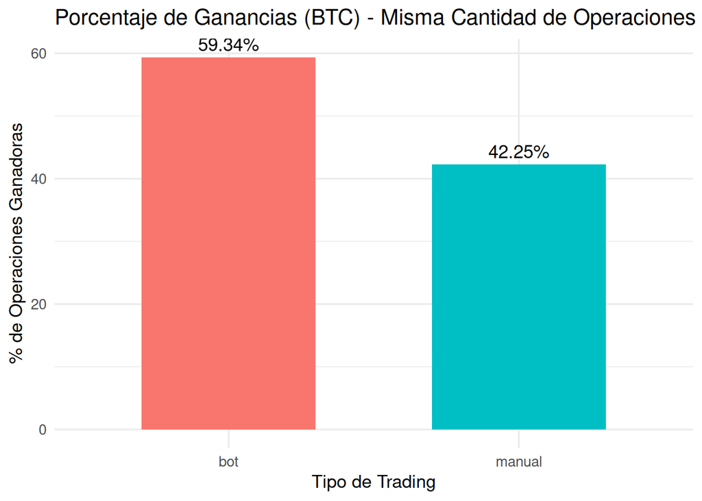

```r
#📊 Paso 5 — Comparación visual sin sesgo
ggplot(tabla_resumen_equal, aes(x = tipo, y = pct_ganancias, fill = tipo)) +
  geom_col(width = 0.6) +
  geom_text(aes(label = paste0(pct_ganancias, "%")), vjust = -0.5) +
  labs(title = "Porcentaje de Ganancias (BTC) - Misma Cantidad de Operaciones",
       x = "Tipo de Trading",
       y = "% de Operaciones Ganadoras") +
  theme_minimal(base_size = 13) +
  theme(legend.position = "none")
```

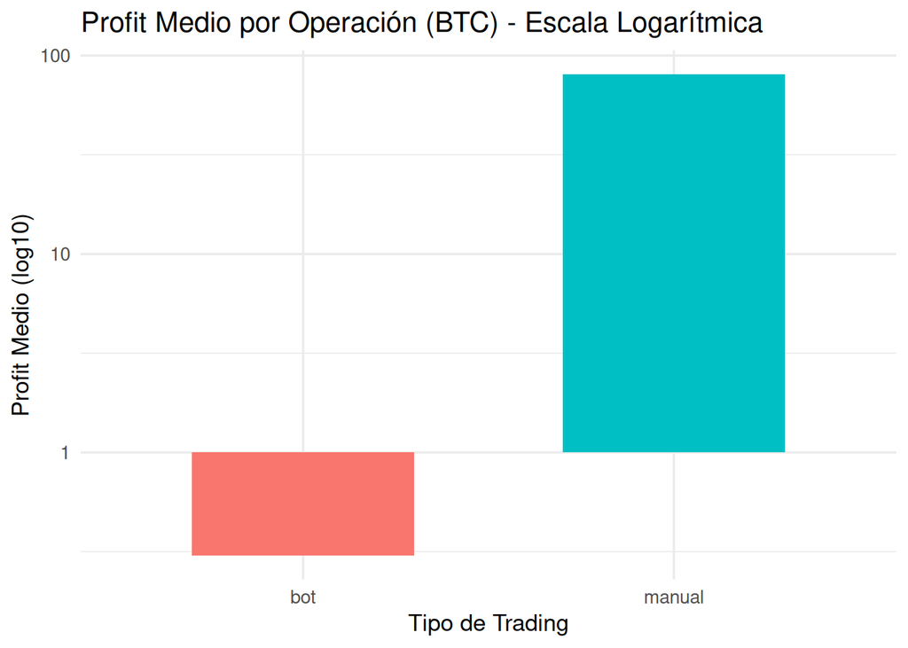

```r
#(Opcional pero recomendable) Comparación de profit medio (barra + error estándar)

ggplot(tabla_resumen_equal, aes(x = tipo, y = media_profit, fill = tipo)) +
  geom_col(width = 0.6) +
  scale_y_log10() +  # Escala logarítmica
  labs(
    title = "Profit Medio por Operación (BTC) - Escala Logarítmica",
    x = "Tipo de Trading",
    y = "Profit Medio (log10)"
  ) +
  theme_minimal(base_size = 13) +
  theme(legend.position = "none")
```

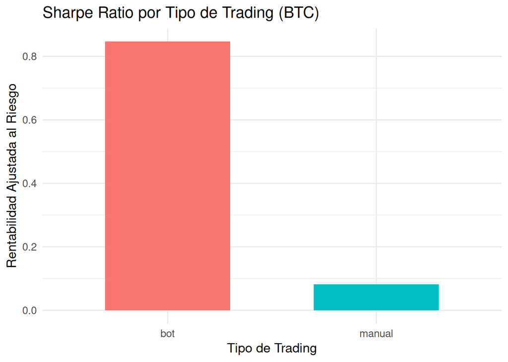

```r
# Sharpe Ratio comparativo
tabla_resumen_equal <- tabla_resumen_equal %>%
  mutate(
    sd_profit = comparativo_btc_equal %>%
      group_by(tipo) %>%
      summarise(sd_profit = sd(profit, na.rm = TRUE)) %>%
      pull(sd_profit),
    sharpe_ratio = ifelse(sd_profit > 0, media_profit / sd_profit, NA)
  )

ggplot(tabla_resumen_equal, aes(x = tipo, y = sharpe_ratio, fill = tipo)) +
  geom_col(width = 0.6) +
  labs(title = "Sharpe Ratio por Tipo de Trading (BTC)",
       x = "Tipo de Trading", y = "Rentabilidad Ajustada al Riesgo") +
  theme_minimal(base_size = 13) +
  theme(legend.position = "none")
```

En esta fase se realizó un análisis estadístico y comparativo entre el bot LSTM y el trading manual para evaluar rentabilidad, consistencia y eficiencia operativa.

Pasos principales:

Preparación de datos:

Se conectaron las bases desde PostgreSQL hacia R.

Se limpiaron y estandarizaron los datasets: keras_q_indicadores, keras_q_operaciones (bot) y trading_manual.

Se unificaron en un solo dataset comparativo con la variable tipo (“bot” o “manual”).

Análisis exploratorio:

Inspección de estructuras, columnas y resúmenes (str, summary, colnames).

Cálculo de métricas descriptivas: media, mediana, desviación estándar, varianza, min/máx, Sharpe Ratio y drawdown máximo.

Identificación de desequilibrio en el número de operaciones: Bot ~3.000 vs Manual ~10.000.

Análisis comparativo:

Visualización de equity acumulado y drawdown para evaluar riesgo y estabilidad.

Comparación de distribución de profits y porcentaje de operaciones ganadoras.

Ajuste por igual número de operaciones para análisis sin sesgo.

Evaluación de profit medio, mediana y Sharpe Ratio por tipo de trading.

Conclusión de la Fase 4: El bot LSTM muestra mayor consistencia y menor riesgo en comparación con el trading manual, aunque las operaciones manuales pueden generar mayores ganancias individuales. La fase permite establecer la base para interpretaciones, recomendaciones y decisiones en la Fase 5.

## Fase 5 – Actuar (Interpretaciones, Recomendaciones y Decisiones)

Objetivo: A partir del análisis estadístico de la Fase 4, interpretar los resultados, generar recomendaciones operativas y tomar decisiones basadas en los hallazgos.

Interpretaciones clave

Porcentaje de aciertos:

Bot: 59%

Manual: 32% (todas las operaciones)

Mismo número de operaciones: Bot 59% vs Manual 42% El bot mantiene ventaja en consistencia y precisión.

Profit por operación:

Manual muestra profits promedio más altos (80.4 USD) comparado con el bot (0.303 USD). Esto indica que el trading manual puede lograr mayores ganancias individuales, probablemente por mayor exposición o tamaño de posición, pero con riesgo más alto.

Volatilidad y riesgo:

Bot tiene menor desviación estándar y drawdown máximo. Menor riesgo relativo y mayor estabilidad del rendimiento a lo largo del tiempo.

Eficiencia operativa:

Bot: ~3.000 operaciones en ~1 mes de forma continua.

Manual: ~10.000 operaciones en un período más amplio, con menor frecuencia y consistencia. el bot permite rendimiento sostenido con menor esfuerzo humano y mayor automatización.

Recomendaciones

Priorizar uso del bot LSTM para operaciones frecuentes y repetitivas.

Monitorear operaciones manuales de alto impacto por riesgo de outliers o resultados extremos.

Evaluar ajustes de Q-Learning para mejorar decisiones del bot y aumentar profit individual.

Mantener registros históricos para análisis continuo y detección de patrones de mercado.

Revisar riesgos éticos y tecnológicos asociados al uso de IA automatizada en trading.

Decisiones estratégicas

Integrar el bot como herramienta principal para trading BTC de alta frecuencia.

Reservar trading manual para operaciones excepcionales o estrategias que requieran juicio humano.

Definir métricas de monitoreo continuo: % de aciertos, drawdown y profit medio.

## Fase 6 – Exponer (Gráficos, Storytelling y Conclusiones)

Objetivo: Comunicar los resultados de manera clara y visual para stakeholders y toma de decisiones ejecutiva.

Dashboards y visualizaciones recomendadas

Equity acumulado + Drawdown:

Línea de equity por operación y sombreado de drawdown para mostrar estabilidad vs riesgo.

Distribución de profits (ECDF):

Comparar la distribución de ganancias por operación entre bot y manual.

Porcentaje de operaciones ganadoras:

Barras comparativas Bot vs Manual, con versión ajustada a igual número de operaciones.

Profit medio por operación:

Barra con escala logarítmica para visualizar diferencias extremas.

Sharpe Ratio:

Barra comparativa para mostrar rentabilidad ajustada al riesgo.

Storytelling ejecutivo

Consistencia: El bot LSTM mantiene alta proporción de aciertos (59%) y menor riesgo, lo que se traduce en estabilidad operacional.

Rentabilidad por operación: El trading manual puede superar al bot en ganancias individuales, pero con alta volatilidad y drawdown.

Eficiencia temporal: El bot logra resultados sostenidos en menor tiempo y con menos esfuerzo humano.

Recomendación final: Combinar la automatización del bot para operaciones regulares y el juicio humano para decisiones estratégicas de alto riesgo.

Conclusión general

El análisis evidencia que el bot LSTM:

Supera al trading manual en consistencia y estabilidad.

Presenta menor volatilidad y drawdown, reduciendo riesgo.

Permite rendimiento sostenido en menor tiempo operativo.

Aunque el trading manual puede generar profits más altos por operación, el bot se recomienda como herramienta principal por eficiencia y confiabilidad.